# Week 4: Text mining 2

SECU0050

Bennett Kleinberg

6 Feb 2020

Data Science for Crime Scientists

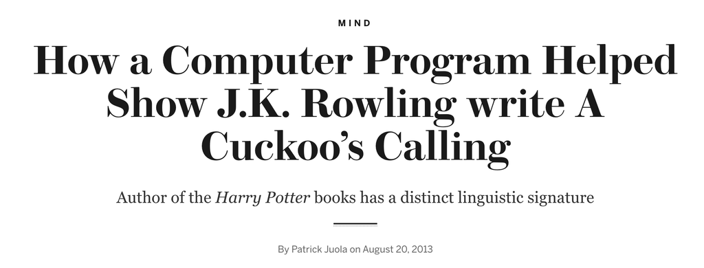

[URL to the article](https://www.scientificamerican.com/article/how-a-computer-program-helped-show-jk-rowling-write-a-cuckoos-calling/)

## Week 4: Text mining 2

## Today

- ngrams
- parts-of-speech
- sentiment analysis
- trajectory analysis

### What is TFIDF?

## Problem?

```
## [1] "It is a great time to be alive"
```

## So far…

- we used tokens as unit of analysis
- but: sometimes multiple tokens might reveal more

## n-grams

= sequences of *n* tokens

- unigrams: n = 1
- bigrams: n = 2
- trigrams: n = 3

## n-grams with quanteda

```r
dfm(x = text
    , ngrams = 1
    , verbose = F
    , remove_punct = T
    , stem = F
    )
```

## Unigrams

```
## Document-feature matrix of: 1 document, 8 features (0% sparse).
## 1 x 8 sparse Matrix of class "dfm"
##        features
## docs    it is a great time to be alive
##   text1  1  1 1     1    1  1  1     1
```

## Bigrams

`ngrams = 2`

```
## Document-feature matrix of: 1 document, 7 features (0% sparse).
## 1 x 7 sparse Matrix of class "dfm"
##        features
## docs    it_is is_a a_great great_time time_to to_be be_alive
##   text1     1    1       1          1       1     1        1
```

## Trigrams

`ngrams = 3`

```
## Document-feature matrix of: 1 document, 6 features (0% sparse).
## 1 x 6 sparse Matrix of class "dfm"
##        features
## docs    it_is_a is_a_great a_great_time great_time_to time_to_be
##   text1       1          1            1             1          1
##        features
## docs    to_be_alive
##   text1           1
```

### What happens when we increase *n*?

## n-grams on a corpus

```r
unigrams = dfm(x = data_corpus_inaugural[1:3]
               , ngrams = 1
               )
```

| document | fellow-citizens | of | the | senate | and |
| --- | --- | --- | --- | --- | --- |
| 1789-Washington | 1 | 71 | 116 | 1 | 48 |
| 1793-Washington | 0 | 11 | 13 | 0 | 2 |
| 1797-Adams | 3 | 140 | 163 | 1 | 130 |

## With preprocessing

```r
unigrams = dfm(x = data_corpus_inaugural[1:3]
               , ngrams = 1
               , stem = T
               , remove = stopwords()
               , remove_punct = T
               )
```

| document | fellow-citizen | senat | hous | repres | among |
| --- | --- | --- | --- | --- | --- |
| 1789-Washington | 1 | 1 | 2 | 2 | 1 |
| 1793-Washington | 0 | 0 | 0 | 0 | 0 |
| 1797-Adams | 3 | 1 | 3 | 3 | 4 |

## Bigrams

```r
bigrams = dfm(x = data_corpus_inaugural[1:3]
                      , ngrams = 2
                      , stem = T
                      , remove = stopwords()
                      , remove_punct = T
                      )
```

| document | fellow-citizen_of | of_the | the_senat | senat_and | and_of |
| --- | --- | --- | --- | --- | --- |
| 1789-Washington | 1 | 20 | 1 | 1 | 2 |
| 1793-Washington | 0 | 4 | 0 | 0 | 1 |
| 1797-Adams | 0 | 29 | 0 | 0 | 2 |

What happens when we increase *n*?

```r
dim(unigrams)
```

```
## [1]   3 892
```

```r
dim(bigrams)
```

```
## [1]    3 3016
```

## Problem?

- essentially we’re back at where we started
- same old problem with <sub>word</sub> ngram importance

```r
dfm_tfidf(bigrams
          , scheme_tf = 'prop'
          , scheme_df = 'inverse'
          , k = 1)
```

| document | fellow-citizen_of | of_the | the_senat | senat_and | and_of |
| --- | --- | --- | --- | --- | --- |
| 1789-Washington | 0.000123 | -0.001749 | 0.000123 | 0.000123 | -0.000175 |
| 1793-Washington | 0.000000 | -0.003730 | 0.000000 | 0.000000 | -0.000932 |
| 1797-Adams | 0.000000 | -0.001564 | 0.000000 | 0.000000 | -0.000108 |

## Multiple n n-grams

```r
dfm(x = text
    , ngrams = 1:3
    , verbose = F
    , remove_punct = T
    , stem = F
    )
```

## *n*-grams

- generalisation of “single” tokens
- often used in [bag-of-word models](https://www.datacamp.com/courses/intro-to-text-mining-bag-of-words)
- common in predictive modelling (Week 7: machine learning 1)

## There’s more to words

- *you can count them (n-grams)*
- *you can “weigh” them (TFIDF)*
- but they also have a function
  - each word has a grammatical function
  - nouns, verbs, pronouns

**Parts-of-speech**

## Bush 2005 inauguration

Tokenisation:

```
##  [1] "Advancing" "these"     "ideals"    "is"        "the"
##  [6] "mission"   "that"      "created"   "our"       "Nation"
## [11] "."
```

## Part-of-speech tagging

POS depend on POS framework.

Commonly used: [Penn Treebank Project](https://www.ling.upenn.edu/courses/Fall_2003/ling001/penn_treebank_pos.html)

## Manual tagging

| Token | POS tag |
| --- | --- |
| Advancing | ? |
| these | ? |
| ideals | ? |
| is | ? |
| the | ? |
| mission | ? |

## POS tagging in R

Using python-to-R bridge with [`spacyr`](https://github.com/quanteda/spacyr)

- relies on spacy (python)
- you need a spacy installation
- package uses python through R

```r
#Wrapper function from
```

## POS tagging with `spacyr`

```
## Finding a python executable with spaCy installed...
```

```
## spaCy (language model: en) is installed in /usr/local/bin/python3
```

```
## successfully initialized (spaCy Version: 2.0.12, language model: en)
```

```
## (python options: type = "python_executable", value = "/usr/local/bin/python3")
```

```r
spacy_parse(as.character(pos_texts$text[1])
            , dependency = FALSE
            , lemma = FALSE
            , pos = TRUE)
```

|  | doc_id | sentence_id | token_id | token | pos | entity |
| --- | --- | --- | --- | --- | --- | --- |
| 407 | text1 | 15 | 1 | Advancing | VERB |  |
| 408 | text1 | 15 | 2 | these | DET |  |
| 409 | text1 | 15 | 3 | ideals | NOUN |  |
| 410 | text1 | 15 | 4 | is | VERB |  |
| 411 | text1 | 15 | 5 | the | DET |  |
| 412 | text1 | 15 | 6 | mission | NOUN |  |

|  | doc_id | sentence_id | token_id | token | pos | entity |
| --- | --- | --- | --- | --- | --- | --- |
| 125 | text1 | 5 | 1 | For | ADP |  |
| 126 | text1 | 5 | 2 | a | DET | DATE_B |
| 127 | text1 | 5 | 3 | half | ADJ | DATE_I |
| 128 | text1 | 5 | 4 | a | DET | DATE_I |
| 129 | text1 | 5 | 5 | century | NOUN | DATE_I |
| 130 | text1 | 5 | 6 | , | PUNCT |  |
| 131 | text1 | 5 | 7 | America | PROPN | GPE_B |
| 132 | text1 | 5 | 8 | defended | VERB |  |
| 133 | text1 | 5 | 9 | our | ADJ |  |
| 134 | text1 | 5 | 10 | own | ADJ |  |
| 135 | text1 | 5 | 11 | freedom | NOUN |  |

## Function wrapper

```r
get_pos_count(df_identifier = pos_texts$id
              , df_textcol = pos_texts$text
              , unique_extr = F
              , pos_type = 'NOUN'
              , verbose = T)
```

*Note: `verbose = T` logs ech POS tag to the console.*

## Getting POS tag counts

```r
noun_counts = get_pos_count(df_identifier = pos_texts$id
                , df_textcol = pos_texts$text
                , unique_extr = F
                , pos_type = 'NOUN'
                , verbose = F)
noun_counts
```

```
## [1] 512 553 486 304
```

## Counting unique POS tags

```r
pronoun_counts = get_pos_count(df_identifier = pos_texts$id
                , df_textcol = pos_texts$text
                , unique_extr = T ## <---
                , pos_type = 'PRON'
                , verbose = F)
pronoun_counts
```

```
## [1] 15 14 13 13
```

## Beyond POS tags

- parse tree dependencies
- named entities

{`spacyr docs`}(https://cloud.r-project.org/web/packages/spacyr/spacyr.pdf) and [spacy core website](https://spacy.io/)

### Sentiment analysis

## Sentiment analysis: aim

- measure positive/negative tone
- “emotionality” of a text
- builds on the “cognition -> language” nexus

## Basic sentiment analysis

1. tokenise text
2. construct a lexicon of sentiment words
3. judge the sentiment words
4. match tokens with sentiment lexicon

Example: YouTube vlog transcripts

## 1. tokenise text

```
## tokens from 1 document.
## caseyneistat_1 :
##    [1] "I"               "think"           "a"
##    [4] "cop"             "is"              "giving"
##    [7] "this"            "guy"             "on"
##   [10] "a"               "bike"            "a"
##   [13] "ticket"          "red"             "light"
##   [16] "apparently"      "like"            "the"
##   [19] "biker"           "I"               "just"
##   [22] "turned"          "red"             "bike"
##   [25] "and"             "well"            "they're"
##   [28] "just"            "posted"          "up"
##   [31] "poor"            "guy"             "those"
##   [34] "good"            "boys"            "this"
##   [37] "close"           "your"            "friends"
```

[output cut: 378 more lines]

## 2. lexicon of sentiment words

- do all words have a potential sentiment?
- maybe focus on adjectives/adverbs, maybe verbs?

Lucky us: many sentiment lexicons exists

## 2. lexicon of sentiment words

The `lexicon` [package](https://github.com/trinker/lexicon)

```
##               x  y
##  1:     abandon -1
##  2:   abandoned -1
##  3: abandonment -1
##  4:        abba  1
##  5:   abduction -1
##  6:    aberrant -1
##  7:  aberration -1
##  8:       abhor -1
##  9:   abhorrent -1
## 10:     ability  1
```

```
##                              x
##  1:                        a a
##  2:      a bad amount of money
##  3:               a bad mother
##  4:    a bad taste in my mouth
##  5:           a bag o' beagles
##  6: a bag of old and moldy ass
##  7:                   a barlow
##  8:                   a barney
##  9:                   a batman
## 10:                    a bitch
```

## lexicon::hash_sentiment_socal_google

```r
head(lexicon::hash_sentiment_socal_google[,1], 10)
```

```
##                   x
##  1:        a pillar
##  2:         ab liva
##  3:            able
##  4:   above average
##  5: above mentioned
##  6:        abrasive
##  7:          absent
##  8:        absolute
##  9:        abstract
## 10:          absurd
```

## 3. judge the sentiment words

Normal strategy

- crowdsourced annotation
- decide on a judgment scale
- multiple judgments per word
- assess inter-rater reliability

## 3. judge the sentiment words

Again: mostly already done for you

```r
head(lexicon::hash_sentiment_nrc, 10)
```

```
##               x  y
##  1:     abandon -1
##  2:   abandoned -1
##  3: abandonment -1
##  4:        abba  1
##  5:   abduction -1
##  6:    aberrant -1
##  7:  aberration -1
##  8:       abhor -1
##  9:   abhorrent -1
## 10:     ability  1
```

Binary judgment: -1 or 1

## Scale judgments

```r
head(lexicon::hash_sentiment_slangsd, 10)
```

```
##                              x    y
##  1:                        a a -0.5
##  2:      a bad amount of money -0.5
##  3:               a bad mother -0.5
##  4:    a bad taste in my mouth -0.5
##  5:           a bag o' beagles -0.5
##  6: a bag of old and moldy ass -0.5
##  7:                   a barlow -0.5
##  8:                   a barney -0.5
##  9:                   a batman  0.5
## 10:                    a bitch -0.5
```

Finer judgment: -1.00, -0.50, 0.50, 1.00

## Continuous judgment

```r
head(lexicon::hash_sentiment_socal_google, 10)
```

```
##                   x          y
##  1:        a pillar  2.9045431
##  2:         ab liva -0.9578700
##  3:            able  2.6393740
##  4:   above average  3.2150018
##  5: above mentioned  2.5815803
##  6:        abrasive  1.6751913
##  7:          absent  0.4850649
##  8:        absolute  0.4737880
##  9:        abstract  2.0068557
## 10:          absurd -3.7778744
```

## 4. match tokens with sentiment lexicon

- Classic approach: one sentiment score [(`syuzhet` package)](https://github.com/mjockers/syuzhet)

> […] was devastated when she found out that she had colon cancer. She entered the third phase of her cancer. It was especially terrifying because her husband passed away from lung cancer after receiving chemotherapy. […]

## 4. match tokens with sentiment lexicon

Classic approach: one sentiment score

```r
syuzhet::get_sentiment(example_text)
```

```
## [1] -1.55
```

Strategy: match words from sentiment lexicon, then calculate a document average.

## Problem?

## 4. match tokens with sentiment lexicon

- Newer approach: sentiment for each sentence

The `sentimentr` [(Rinker)](https://github.com/trinker/sentimentr) package

```r
sentimentr::sentiment(example_text)
```

```
##    element_id sentence_id word_count  sentiment
## 1:          1           1         16 -0.1625000
## 2:          1           2          8 -0.2651650
## 3:          1           3         15 -0.5034878
## 4:          1           4         12 -0.1443376
## 5:          1           5         16 -0.4218750
```

## 4. match tokens with sentiment lexicon

- Newer approach: sentiment for each sentence
  - needs punctuated data
  - requires good sentence disambiguation
  - without punctuation: whole string = 1 sentence
- What about valence shifters?

This is not ideal.

## Sentiment trajectory analysis

Papers: [vlogs](https://arxiv.org/pdf/1808.09722.pdf), [news channels](https://www.aclweb.org/anthology/W19-2110.pdf), [drill lyrics](https://arxiv.org/pdf/1911.01324.pdf)

Idea: - sentiment is dynamic within texts - static approaches mask sentiment dynamics - worst case: sentiment completely off

Inspired by Matthew Jockers’ [work](http://www.matthewjockers.net/2015/02/02/syuzhet/)

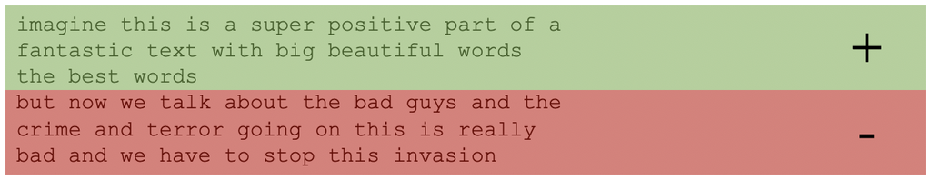

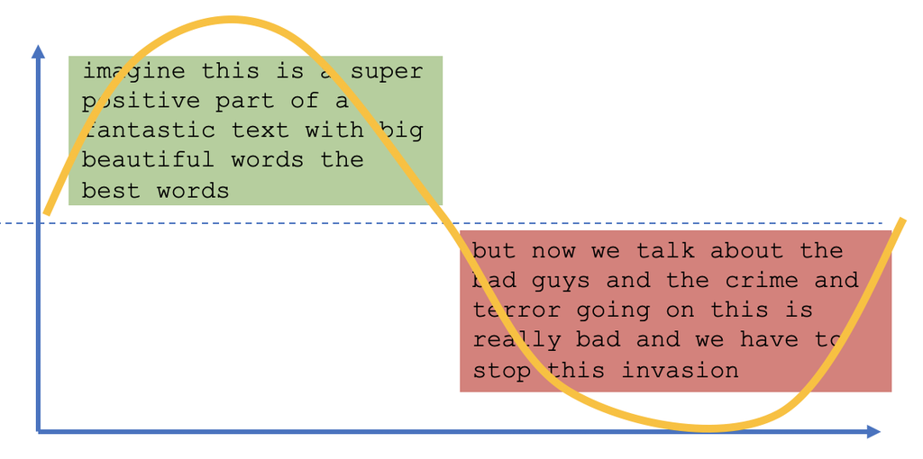

## Sentiment trajectories

1. Parse text input into words
2. Match sentiment lexicon to each word
   - Match valence shifters to each context
     - Apply valence shifter weights
     - Build a naïve context around the sentiment
     - Return modified sentiment

## Sentiment trajectory analysis

Package from: `https://github.com/ben-aaron188/naive_context_sentiment`

```
## [1] "For external lexicon-databases, please set the current wd to the parent of the ncs function (e.g. the GitHub repo)"
```

| text | index |
| --- | --- |
| it | 25 |
| was | 26 |
| especially | 27 |
| terrifying | 28 |
| because | 29 |
| her | 30 |
| husband | 31 |
| passed | 32 |
| away | 33 |
| from | 34 |
| lung | 35 |

## Match sentiment

| text | index | y |
| --- | --- | --- |
| it | 25 | NA |
| was | 26 | NA |
| especially | 27 | NA |
| terrifying | 28 | -1 |
| because | 29 | NA |
| her | 30 | NA |
| husband | 31 | NA |
| passed | 32 | NA |
| away | 33 | NA |
| from | 34 | NA |
| lung | 35 | NA |

## Match valence shifters

| text | index | y.x | y.y |
| --- | --- | --- | --- |
| it | 25 | NA | NA |
| was | 26 | NA | NA |
| especially | 27 | NA | 2 |
| terrifying | 28 | -1 | NA |
| because | 29 | NA | NA |
| her | 30 | NA | NA |
| husband | 31 | NA | NA |
| passed | 32 | NA | NA |
| away | 33 | NA | NA |
| from | 34 | NA | NA |
| lung | 35 | NA | NA |

## Valence shifters

- 1 = negator (not, never, …):-1.00
- 2 = amplifier (very, totally, …): 1.50
- 3 = deamplifier (hardly, barely, …): 0.50
- 4 = adversative conjunction (but, however, …): 0.25

## Apply valence shifter weights

| text | index | sentiment | valence | weights |
| --- | --- | --- | --- | --- |
| it | 25 | NA | NA | 1.0 |
| was | 26 | NA | NA | 1.0 |
| especially | 27 | NA | 2 | 1.5 |
| terrifying | 28 | -1 | NA | 1.0 |
| because | 29 | NA | NA | 1.0 |
| her | 30 | NA | NA | 1.0 |
| husband | 31 | NA | NA | 1.0 |
| passed | 32 | NA | NA | 1.0 |
| away | 33 | NA | NA | 1.0 |
| from | 34 | NA | NA | 1.0 |
| lung | 35 | NA | NA | 1.0 |

## Sentiment trajectories

Build ‘naive’ context around sentiment

- 2 words around sentiment word

| text | index | sentiment | valence | weights |
| --- | --- | --- | --- | --- |
| **was** | 26 | NA | NA | 1.0 |
| **especially** | 27 | NA | 2 | 1.5 |
| **terrifying** | 28 | -1 | NA | 1.0 |
| **because** | 29 | NA | NA | 1.0 |
| **her** | 30 | NA | NA | 1.0 |

## Calculate modified sentiment

```
## [1] "sentiment change for \"devastated\": -0.5 --> -0.5"
## [1] "sentiment change for \"found\": 0.6 --> 0.6"
## [1] "sentiment change for \"cancer\": -0.75 --> -0.75"
## [1] "sentiment change for \"cancer\": -0.75 --> -0.75"
## [1] "sentiment change for \"terrifying\": -1 --> -1.5"
## [1] "sentiment change for \"cancer\": -0.75 --> -0.75"
## [1] "sentiment change for \"receiving\": 0.6 --> 0.6"
## [1] "sentiment change for \"exposed\": -0.5 --> -0.125"
## [1] "sentiment change for \"cancer\": -0.75 --> -0.75"
```

| text | sentiment | valence | weights | sentiment_score_mod |
| --- | --- | --- | --- | --- |
| was | NA | NA | 1.0 | 0.0 |
| especially | NA | 2 | 1.5 | 0.0 |
| terrifying | -1 | NA | 1.0 | -1.5 |
| because | NA | NA | 1.0 | 0.0 |
| her | NA | NA | 1.0 | 0.0 |

## Trajectories

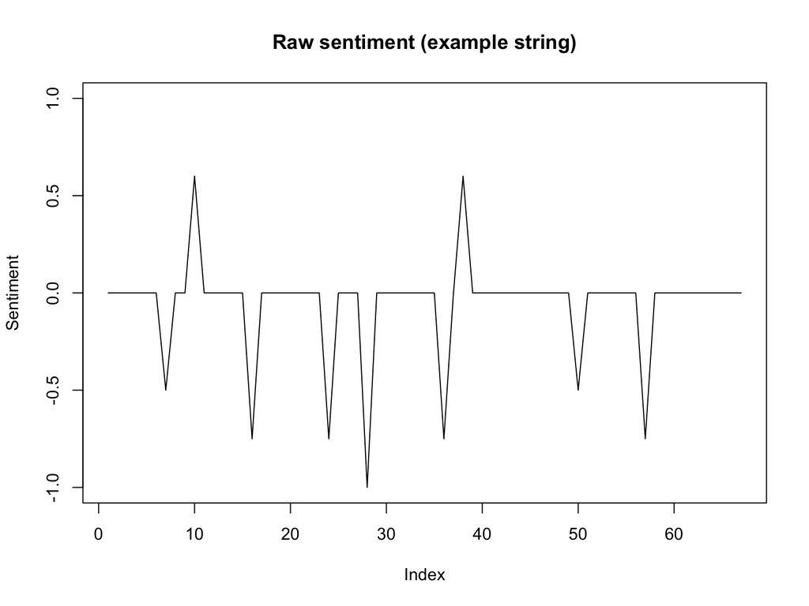

## Vlog data

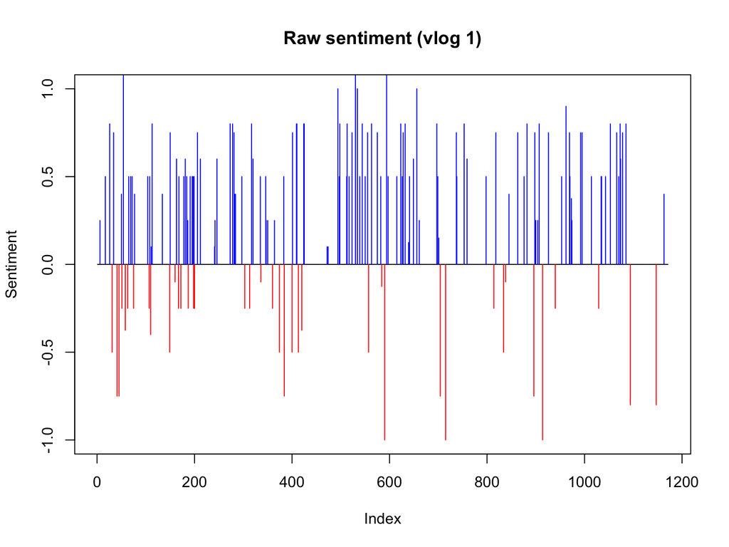

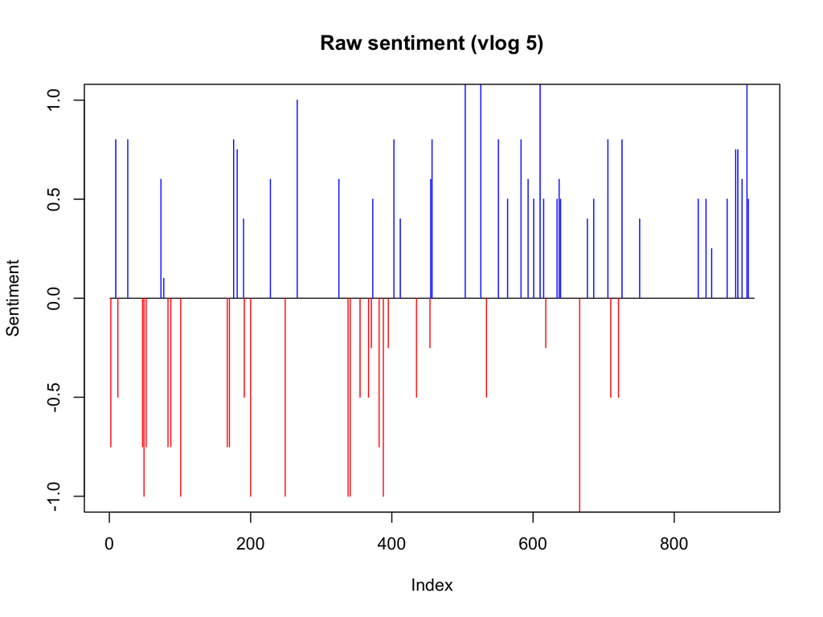

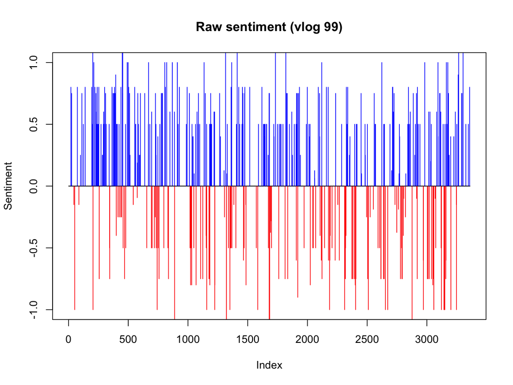

## Problem?

## Solution: Length-standardisation

- aim: transform all sentiment values to a vector
- standard vector length for comparisons
- here: 100 values with [Discrete Cosine Transformation](https://link.springer.com/referenceworkentry/10.1007%2F0-387-30038-4_61) ([explainer on Fourier Transformation](https://www.youtube.com/watch?v=mkGsMWi_j4Q))

## After Discrete Cosine Transformation

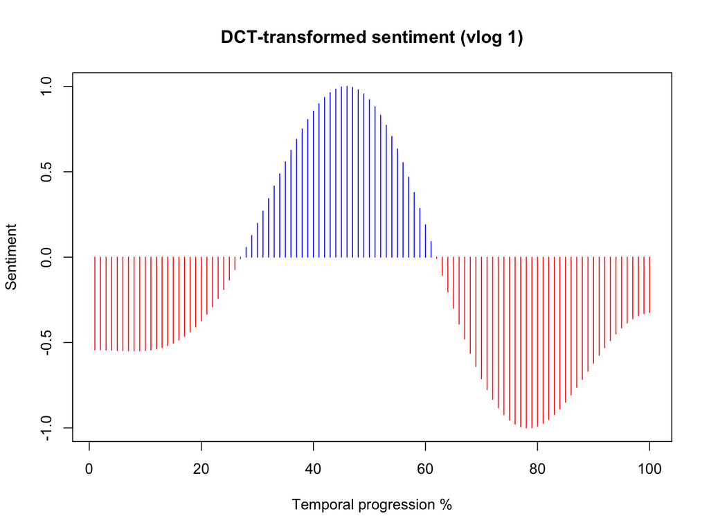

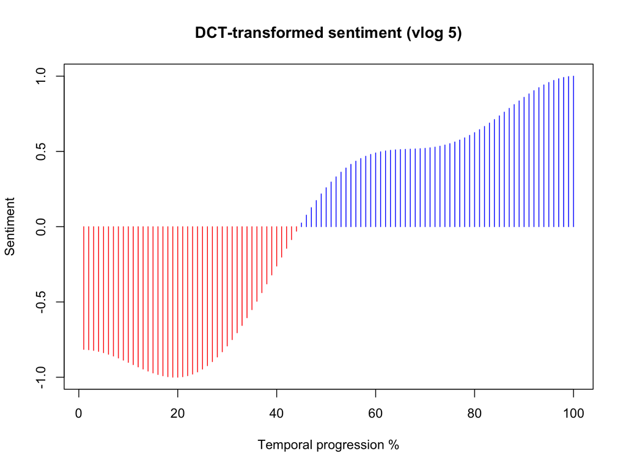

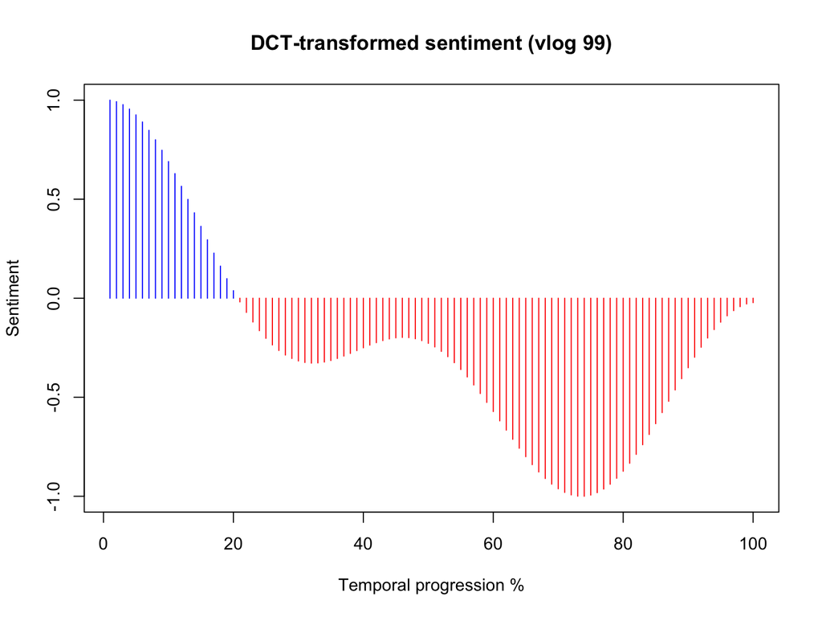

## Beware of the “filter” size

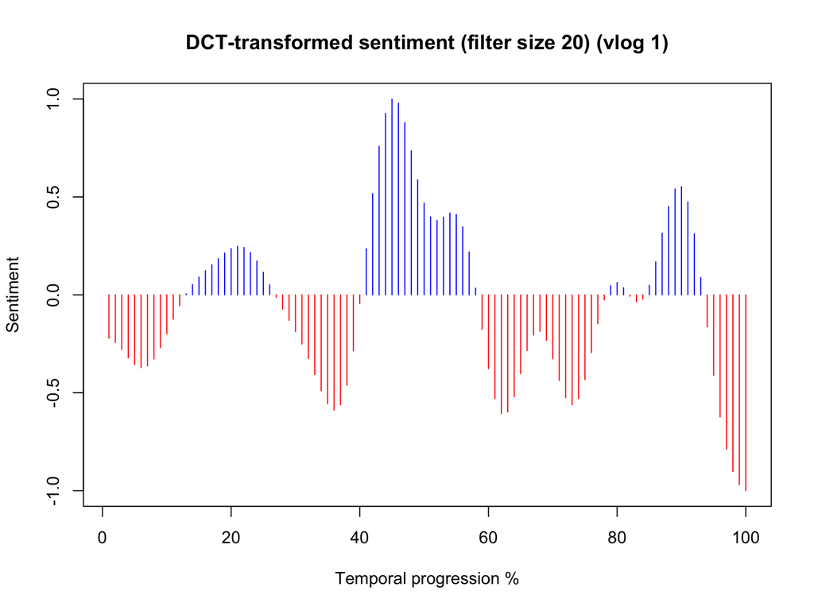

## What’s next?

- Today’s tutorial: ngrams, POS tagging, sentiment analysis, trajectory analysis
- Homework: KWIC analysis, trajectory parameters

Next week: Text Mining 3